# Creating images with R

with a little bit of magick

Linh Ha

```css
body {
font-family: Times;
background-color: #afcfa3;
color: #ffffff;
font-size: 18px;
}

h1 {
font-weight: bold;
color: #d1dea9;
background-color: #7a9c57;
text-align: center;
text-transform: uppercase;
}

h2 {
font-weight: bold;
color: #7a9c57;
background-color: #d1dea9;
}
```

## Project requirements

I’ve used three different levels of headers for my GitHub. The biggest header is titled “STATS220 Repository”, and beneath it is a sentence in *italics* that announces the purpose of the repository. Underneath the second biggest header titled “About me,” I wrote a short paragraph introducing myself with my name printed in **bold**. I listed a couple of pieces of academic information about myself in bullet points. I also used an order list to tell some fun facts about me and included a small header at the top of the list. A link that leads to a video of a Finnegan fox laughing is included at the end of the file.

Here’s the [link](https://github.com/lha492/stats220) to my repo. Take a look at [my website](https://lha492.github.io/stats220/project1_report.html) as well!

[figure not shown]

*A screenshot of the project folder I have created using markdown.*

## My meme

[figure not shown]

The original image is an ironic meme featuring a man pretending to read a book on the subway, accompanied by the caption “His ass is not reading.” To maintain the humor of the meme, I prioritize two key components: the subject’s apparent lack of interest in reading and the memorable catchphrase. In my version of the meme, I replace the man with a bunch of cats because, in my opinion, pets and animals possess a unique appeal that humans can’t replicate easily. To me, everything they do seems ten times funnier compared to when a human does it.

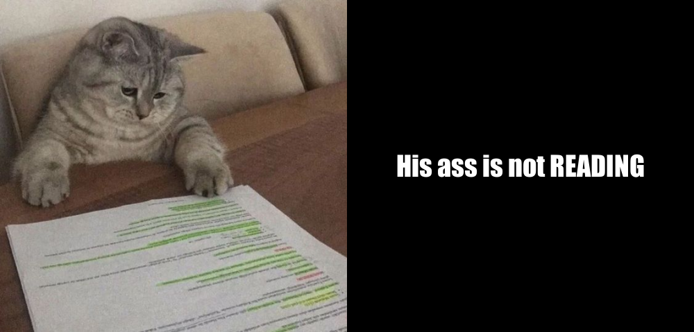

```r
library(magick)

# creating a black square with added text
black_square <- image_blank(width = 500,
                            height = 479,
                            color = "#000000") %>%
  image_annotate(text = "His ass is not READING",
                 size = 40,
                 color = "#FFFFFF",
                 gravity = "center",
                 font = "Impact")

# adding 4 cat images which will be used for the animation
first_cat <- image_read("cat1.png") %>%
  image_scale(500)

second_cat <- image_read("cat2.png") %>%
  image_scale(500)

third_cat <- image_read("cat3.png") %>%
  image_scale(500)

fourth_cat <- image_read("cat4.png") %>%
  image_scale(500)

#creating 4 frames, each frame is a concatenation of a cat image with the black square with added text

first_frame <- c(first_cat, black_square) %>%
  image_append()

second_frame <- c(second_cat, black_square) %>%
  image_append()

third_frame <- c(third_cat, black_square) %>%
  image_append()

fourth_frame <- c(fourth_cat, black_square) %>%
  image_append()

#creating the meme without animation
first_frame
```

```r
# saving first_frame (meme without animation) as a png file
image_write(first_frame, "my_meme.png")
```

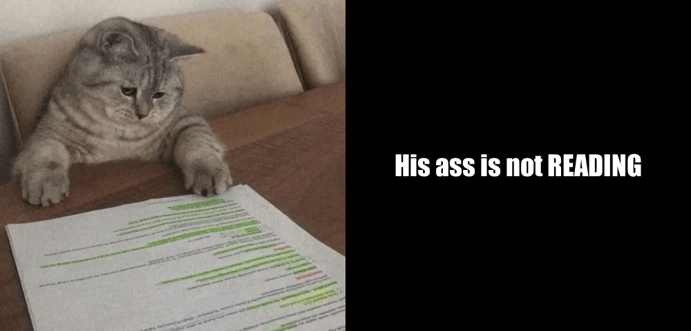

```r
# putting the frames together using a vector
frames <- c(first_frame, second_frame, third_frame, fourth_frame)

# creating the meme with animation
animation <- frames %>%
  image_animate(fps = 1)

#saving the meme with animation as a gif file
image_write(animation, "my_animation.gif")
```

## Creativity

I have not only utilized CSS to modify the appearance of my HTML but have also gone beyond the basic requirements, implementing additional styling techniques beyond what was taught and utilising a nice green color scheme to create a more visually appealing web page. Additionally, I have successfully deployed the website using GitHub.

## Learning reflection

I had some prior exposure to HTML before starting this course, although it was not very in-depth, and I always struggled with its syntax. I wasn’t aware that we could write code in a more user-friendly language and then convert it to HTML. I appreciate that the module introduced me to Markdown because it significantly reduces visual clutter and is far simpler to work with than coding raw HTML.

Another important lesson I gained from this module is how to adopt a project-oriented workflow, maintain organized and well-named projects, and understand the importance of doing so. I’ve never been the most organized person but learning this has helped me discipline myself to treat my work more carefully while ensuring that my projects are structured and reproducible.

I had a lot of fun learning and using a new coding language to create humorous memes. I look forward to future projects when we also get to do activities that encourage learning and creative thinking.